# Ćwiczenie 2 (tidymodels)

- Show All Code
- Hide All Code
- View Source

Author

Jakub Anczyk

## 1 Sprawdzenie opisu danych

Pobieranie danych i ich wstępna analiza.

**Show and hide code**

```r
air <- mydata |> selectByDate(year = 2002)
air |> skim()
```

Data summary

| Name | air |
| --- | --- |
| Number of rows | 8760 |
| Number of columns | 10 |
| _______________________ |  |
| Column type frequency: |  |
| numeric | 9 |
| POSIXct | 1 |
| ________________________ |  |
| Group variables | None |

**Variable type: numeric**

| skim_variable | n_missing | complete_rate | mean | sd | p0 | p25 | p50 | p75 | p100 | hist |
| --- | --- | --- | --- | --- | --- | --- | --- | --- | --- | --- |
| ws | 13 | 1.00 | 5.05 | 2.74 | 0.5 | 3.09 | 4.60 | 6.57 | 19.60 | ▇▇▂▁▁ |
| wd | 27 | 1.00 | 193.18 | 93.20 | 0.0 | 130.00 | 200.00 | 250.00 | 360.00 | ▅▃▇▆▅ |
| nox | 135 | 0.98 | 156.62 | 100.01 | 7.0 | 75.00 | 137.00 | 220.00 | 695.00 | ▇▆▂▁▁ |
| no2 | 135 | 0.98 | 41.98 | 16.66 | 4.0 | 30.00 | 40.00 | 52.00 | 124.00 | ▃▇▃▁▁ |
| o3 | 263 | 0.97 | 7.38 | 8.04 | 0.0 | 2.00 | 4.00 | 10.00 | 52.00 | ▇▂▁▁▁ |
| pm10 | 163 | 0.98 | 34.12 | 17.39 | 1.0 | 22.00 | 32.00 | 43.00 | 511.00 | ▇▁▁▁▁ |
| so2 | 307 | 0.96 | 3.74 | 2.83 | 0.0 | 1.75 | 3.25 | 5.00 | 35.25 | ▇▁▁▁▁ |
| co | 216 | 0.98 | 1.24 | 0.78 | 0.0 | 0.60 | 1.05 | 1.70 | 4.58 | ▇▆▃▁▁ |
| pm25 | 618 | 0.93 | 21.43 | 9.94 | 0.0 | 14.00 | 20.00 | 27.00 | 112.00 | ▇▅▁▁▁ |

**Variable type: POSIXct**

| skim_variable | n_missing | complete_rate | min | max | median | n_unique |
| --- | --- | --- | --- | --- | --- | --- |
| date | 0 | 1 | 2002-01-01 | 2002-12-31 23:00:00 | 2002-07-02 11:30:00 | 8760 |

**Show and hide code**

```r
air <- air |> na.omit()
```

## 2 Wizualizacja zmiennych NOx i NO2

Porównanie korelacji pomiędzy zmiennymi NOx i NO2 na podstawie próby 300 obserwacji.

**Show and hide code**

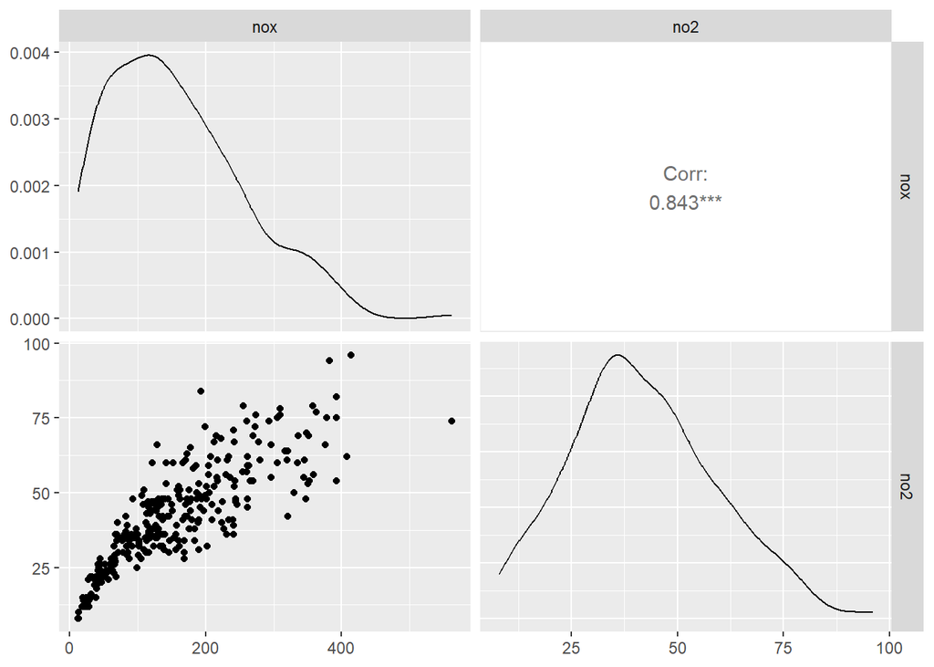

```r
set.seed(222)
air[sample(1:nrow(air), size = 300, replace = F),] |>
  select(nox, no2) |>
  ggpairs()
```

## 3 Wykres punktowy z linią regresji

Wizualizacja regresji liniowej dla zmiennych NOx i NO2.

**Show and hide code**

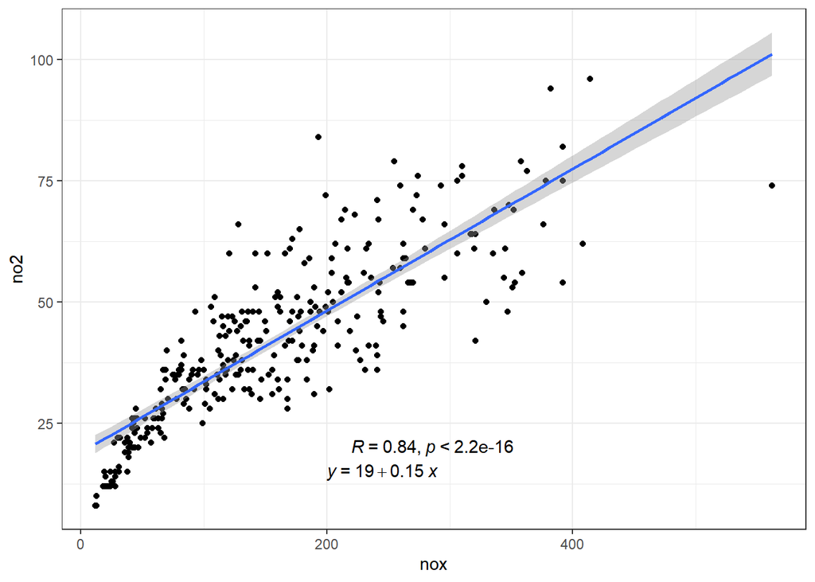

```r
set.seed(222)
air[sample(1:nrow(air), size = 300, replace = F),] |>
  select(nox, no2) |>
  ggplot(aes(nox, no2)) +
  geom_point() +
  geom_smooth(method = "lm", se = T, formula = y ~ x) +
  stat_cor(label.x = 220, label.y = 20) +
  stat_regline_equation(label.x = 200, label.y = 15) +
  theme_bw()
```

## 4 Wykres stężenia ozonu w czasie

Wykres liniowy przedstawiający zmienność poziomu ozonu w czasie.

**Show and hide code**

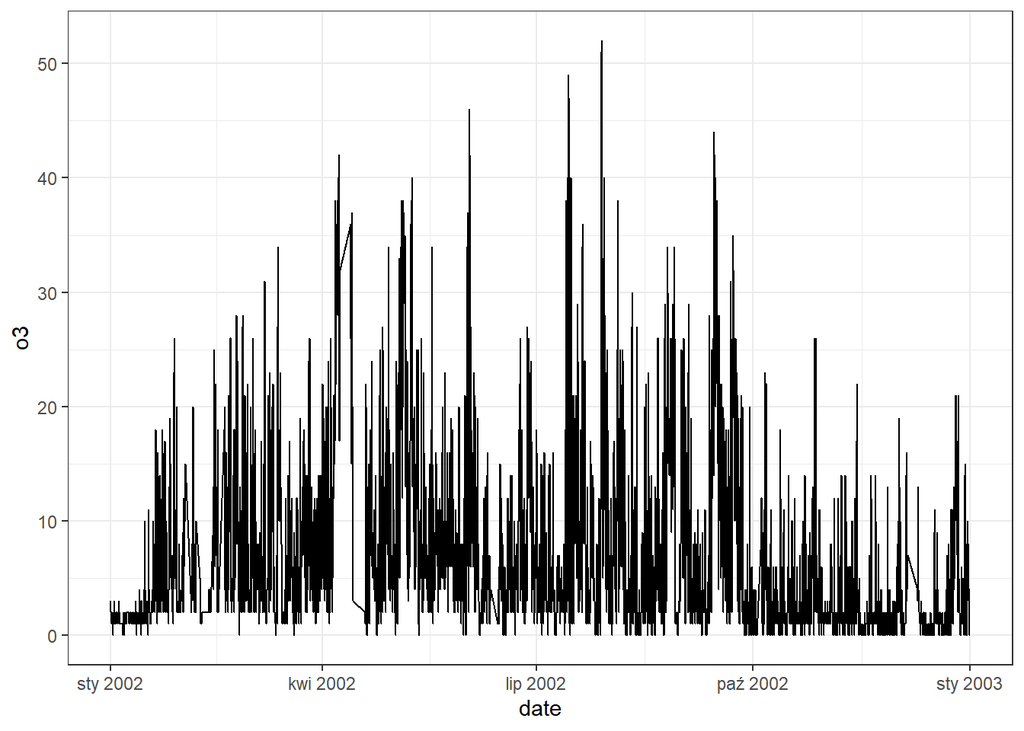

```r
air |>
  ggplot(aes(date, o3)) +
  geom_line() +
  theme_bw()
```

## 5 Zakres wartości O3

Obliczenie zakresu wartości zmiennej O3.

**Show and hide code**

```r
air |>
  pull(o3) |>
  range()
```

```
[1]  0 52
```

## 6 Liczba kombinacji zmiennych predykcyjnych

Obliczenie liczby możliwych kombinacji zmiennych predykcyjnych.

**Show and hide code**

```r
(kombinacje <- (2^length(setdiff(names(air %>% select(-date)), "o3"))) - 1)
```

```
[1] 255
```

## 7 Algorytm Hellwiga

Implementacja algorytmu Hellwiga dla wyboru najlepszego modelu predykcyjnego.

**Show and hide code**

```r
hellwig <- function(y, x, method = "pearson") {
  requireNamespace("utils")
  x <- x[sapply(x, is.numeric)]  # Ensure only numeric predictors
  x <- as.data.frame(x)  # Convert to data frame

  # Calculate correlation matrix
  cm <- stats::cor(x, method = method)  # Correlations between predictors
  cd <- stats::cor(x, y, method = method)  # Correlation between predictors and target

  # Generate all subsets of the predictors
  k <- sapply(seq(2, ncol(x)), function(i) utils::combn(ncol(x), i, simplify = FALSE))
  k <- do.call("c", k)

  # Hellwig function to calculate score for a subset
  hfun <- function(v) {
    sapply(v, function(i) cd[i]^2 / sum(abs(cm[v, i])))
  }

  # Store all combinations and their respective scores
  all_combinations <- lapply(k, function(comb) {
    score <- sum(hfun(comb))
    list(combination = paste(names(x)[comb], collapse = "-"), score = score)
  })

  # Convert to data frame for easy viewing
  all_combinations_df <- data.frame(
    combination = sapply(all_combinations, `[[`, "combination"),
    score = sapply(all_combinations, `[[`, "score"),
    stringsAsFactors = FALSE
  )

  # Return the data frame of all combinations and their scores
  return(all_combinations_df)
}

target_var <- c("o3")
predictor_sets <- setdiff(names(air %>% select(-date)), target_var)

predictor_data <- air[, predictor_sets]
target_data <- air[[target_var]]

all_models <- hellwig(target_data, predictor_data, method = "pearson")
best_model <- all_models |> slice(which.max(score))
best_model
```

```
  combination     score
1      ws-nox 0.3808659
```

## 8 Klasyfikacja poziomu ozonu

Klasyfikacja wartości ozonu na kategorie: “Niskie” i “Wysokie” oraz zawężenie liczby kolumn do podzbioru z najlepszym wynikiem pojemności informacyjnej według metody Hellwiga.

**Show and hide code**

```r
air <-
  air |>
  mutate(ozone = cut(
    o3,
    breaks = c(-0.1, 10, 53),
    labels = c("Niskie", "Wysokie")
  )) |>
  select(c(ozone, ws, nox))
```

## 9 Licznik wartości ozonu

Obliczenie liczby przypadków i proporcji dla poziomu ozonu.

**Show and hide code**

```r
air |>
  count(ozone) |>
  mutate(prop = n/sum(n))
```

```
# A tibble: 2 × 3
  ozone       n  prop
  <fct>   <int> <dbl>
1 Niskie   5762 0.763
2 Wysokie  1794 0.237
```

## 10 Ponowna analiza danych

Przegląd i podsumowanie danych po klasyfikacji.

**Show and hide code**

```r
air |>
  skimr::skim()
```

Data summary

| Name | air |
| --- | --- |
| Number of rows | 7556 |
| Number of columns | 3 |
| _______________________ |  |
| Column type frequency: |  |
| factor | 1 |
| numeric | 2 |
| ________________________ |  |
| Group variables | None |

**Variable type: factor**

| skim_variable | n_missing | complete_rate | ordered | n_unique | top_counts |
| --- | --- | --- | --- | --- | --- |
| ozone | 0 | 1 | FALSE | 2 | Nis: 5762, Wys: 1794 |

**Variable type: numeric**

| skim_variable | n_missing | complete_rate | mean | sd | p0 | p25 | p50 | p75 | p100 | hist |
| --- | --- | --- | --- | --- | --- | --- | --- | --- | --- | --- |
| ws | 0 | 1 | 4.98 | 2.67 | 0.5 | 3.1 | 4.6 | 6.49 | 18.87 | ▇▇▂▁▁ |
| nox | 0 | 1 | 160.50 | 99.97 | 7.0 | 80.0 | 143.0 | 223.00 | 695.00 | ▇▆▂▁▁ |

## 11 Podział danych

Podział danych na zbiór treningowy i testowy.

**Show and hide code**

```r
set.seed(222)
data_split <- initial_split(data = air, prop = 3/4)
train_data <- training(data_split)
test_data <-  testing(data_split)
```

## 12 Receptura i rola

Definicja receptury przekształceń zmiennych w modelu.

**Show and hide code**

```r
air_rec <-
  recipe(ozone ~., data = train_data)
```

## 13 Przygotowanie danych do trenowania

Wstępne przekształcenie danych treningowych.

**Show and hide code**

```r
air_rec |> prep() |> bake(train_data) |> _[1:10,] |> DT::datatable()
```

|  | ws | nox | ozone |
| --- | --- | --- | --- |
| 1 | 3.986765 | 262 | Niskie |
| 2 | 4.505641 | 133 | Niskie |
| 3 | 2.724609 | 209 | Niskie |
| 4 | 2.02644 | 310 | Niskie |
| 5 | 3.6 | 76 | Niskie |
| 6 | 5.2 | 335 | Niskie |
| 7 | 4.498426 | 25 | Wysokie |
| 8 | 0.9503843 | 20 | Wysokie |
| 9 | 3.115914 | 190 | Niskie |
| 10 | 4.472133 | 19 | Wysokie |

**Show and hide code**

```r
air_rec |> prep()
```

## 14 Model regresji logistycznej

Utworzenie modelu regresji logistycznej.

**Show and hide code**

```r
lr_mod <-
  logistic_reg() |>
  set_engine("glm")
```

## 15 Praca z przepływem danych

Zdefiniowanie przepływu danych w celu trenowania modelu.

**Show and hide code**

```r
logi_work <-
  workflow() |>
  add_model(lr_mod) |>
  add_recipe(air_rec)

logi_work
```

```
══ Workflow ════════════════════════════════════════════════════════════════════
Preprocessor: Recipe
Model: logistic_reg()

── Preprocessor ────────────────────────────────────────────────────────────────
0 Recipe Steps

── Model ───────────────────────────────────────────────────────────────────────
Logistic Regression Model Specification (classification)

Computational engine: glm
```

## 16 Trenowanie modelu

Trenowanie modelu na danych treningowych.

**Show and hide code**

```r
logi_fit <-
  logi_work |>
  fit(data = train_data)
```

## 17 Wyciągnięcie parametrów modelu

Ekstrakcja parametrów dopasowanego modelu.

**Show and hide code**

```r
logi_fit |>
  extract_fit_parsnip() |>
  tidy()
```

```
# A tibble: 3 × 5
  term        estimate std.error statistic   p.value
  <chr>          <dbl>     <dbl>     <dbl>     <dbl>
1 (Intercept)   0.870    0.112        7.78 7.15e- 15
2 ws            0.317    0.0170      18.6  3.97e- 77
3 nox          -0.0337   0.00107    -31.5  3.29e-217
```

## 18 Ekstrakcja przepisu

Wyciągnięcie przepisu z dopasowanego modelu.

**Show and hide code**

```r
logi_fit |>
  extract_recipe()
```

## 19 Predykcja na danych testowych

Predykcja wartości na podstawie zbioru testowego.

**Show and hide code**

```r
pred_test <-
  augment(logi_fit, test_data)

pred_test
```

```
# A tibble: 1,889 × 6
   .pred_class .pred_Niskie .pred_Wysokie ozone     ws   nox
   <fct>              <dbl>         <dbl> <fct>  <dbl> <int>
 1 Niskie             1.00     0.00000277 Niskie 1.70    422
 2 Niskie             1.00     0.0000164  Niskie 1.79    370
 3 Niskie             1.00     0.000162   Niskie 0.840   293
 4 Niskie             1.00     0.0000829  Niskie 1.70    321
 5 Niskie             1.00     0.000440   Niskie 2.93    283
 6 Niskie             0.992    0.00833    Niskie 3.63    202
 7 Niskie             0.991    0.00942    Niskie 3.70    199
 8 Niskie             0.945    0.0545     Niskie 3.12    140
 9 Niskie             0.993    0.00733    Niskie 4.18    211
10 Niskie             0.868    0.132      Niskie 2.79    108
# ℹ 1,879 more rows
```

## 20 Krzywa ROC

Wizualizacja krzywej ROC dla wyników predykcji.

**Show and hide code**

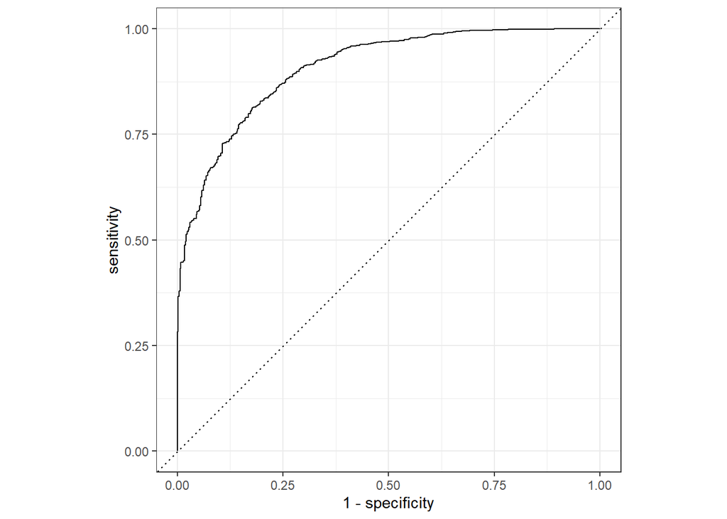

```r
pred_test  |>
  roc_curve(truth = ozone, .pred_Niskie) |>
  autoplot()
```

## 21 Pole pod krzywą ROC

Obliczenie pola pod krzywą ROC dla wyników predykcji.

**Show and hide code**

```r
pred_test |>
  roc_auc(truth = ozone, .pred_Niskie)
```

```
# A tibble: 1 × 3
  .metric .estimator .estimate
  <chr>   <chr>          <dbl>
1 roc_auc binary         0.907
```